# Session 6: Homework 3

MAM Group 5

2021-09-12

# 1 Youth Risk Behavior Surveillance

Every two years, the Centers for Disease Control and Prevention conduct the [Youth Risk Behavior Surveillance System (YRBSS)](https://www.cdc.gov/healthyyouth/data/yrbs/index.htm) survey, where it takes data from high schoolers (9th through 12th grade), to analyze health patterns. You will work with a selected group of variables from a random sample of observations during one of the years the YRBSS was conducted.

## 1.1 Load the data

This data is part of the `openintro` textbook and we can load and inspect it. There are observations on 13 different variables, some categorical and some numerical. The meaning of each variable can be found by bringing up the help file:

```r
?yrbss
```

```r
data(yrbss)
glimpse(yrbss)
```

```
## Rows: 13,583
## Columns: 13
## $ age                      <int> 14, 14, 15, 15, 15, 15, 15, 14, 15, 15, 15, 1…
## $ gender                   <chr> "female", "female", "female", "female", "fema…
## $ grade                    <chr> "9", "9", "9", "9", "9", "9", "9", "9", "9", …
## $ hispanic                 <chr> "not", "not", "hispanic", "not", "not", "not"…
## $ race                     <chr> "Black or African American", "Black or Africa…
## $ height                   <dbl> NA, NA, 1.73, 1.60, 1.50, 1.57, 1.65, 1.88, 1…
## $ weight                   <dbl> NA, NA, 84.4, 55.8, 46.7, 67.1, 131.5, 71.2, …
## $ helmet_12m               <chr> "never", "never", "never", "never", "did not …
## $ text_while_driving_30d   <chr> "0", NA, "30", "0", "did not drive", "did not…
## $ physically_active_7d     <int> 4, 2, 7, 0, 2, 1, 4, 4, 5, 0, 0, 0, 4, 7, 7, …
## $ hours_tv_per_school_day  <chr> "5+", "5+", "5+", "2", "3", "5+", "5+", "5+",…
## $ strength_training_7d     <int> 0, 0, 0, 0, 1, 0, 2, 0, 3, 0, 3, 0, 0, 7, 7, …
## $ school_night_hours_sleep <chr> "8", "6", "<5", "6", "9", "8", "9", "6", "<5"…
```

Before you carry on with your analysis, it’s is always a good idea to check with `skimr::skim()` to get a feel for missing values, summary statistics of numerical variables, and a very rough histogram.

```r
skim(yrbss)
```

Data summary

| Name | yrbss |
| --- | --- |
| Number of rows | 13583 |
| Number of columns | 13 |
| _______________________ |  |
| Column type frequency: |  |
| character | 8 |
| numeric | 5 |
| ________________________ |  |
| Group variables | None |

**Variable type: character**

| skim_variable | n_missing | complete_rate | min | max | empty | n_unique | whitespace |
| --- | --- | --- | --- | --- | --- | --- | --- |
| gender | 12 | 1.00 | 4 | 6 | 0 | 2 | 0 |
| grade | 79 | 0.99 | 1 | 5 | 0 | 5 | 0 |
| hispanic | 231 | 0.98 | 3 | 8 | 0 | 2 | 0 |
| race | 2805 | 0.79 | 5 | 41 | 0 | 5 | 0 |
| helmet_12m | 311 | 0.98 | 5 | 12 | 0 | 6 | 0 |
| text_while_driving_30d | 918 | 0.93 | 1 | 13 | 0 | 8 | 0 |
| hours_tv_per_school_day | 338 | 0.98 | 1 | 12 | 0 | 7 | 0 |
| school_night_hours_sleep | 1248 | 0.91 | 1 | 3 | 0 | 7 | 0 |

**Variable type: numeric**

| skim_variable | n_missing | complete_rate | mean | sd | p0 | p25 | p50 | p75 | p100 | hist |
| --- | --- | --- | --- | --- | --- | --- | --- | --- | --- | --- |
| age | 77 | 0.99 | 16.16 | 1.26 | 12.00 | 15.0 | 16.00 | 17.00 | 18.00 | ▁▂▅▅▇ |
| height | 1004 | 0.93 | 1.69 | 0.10 | 1.27 | 1.6 | 1.68 | 1.78 | 2.11 | ▁▅▇▃▁ |
| weight | 1004 | 0.93 | 67.91 | 16.90 | 29.94 | 56.2 | 64.41 | 76.20 | 180.99 | ▆▇▂▁▁ |
| physically_active_7d | 273 | 0.98 | 3.90 | 2.56 | 0.00 | 2.0 | 4.00 | 7.00 | 7.00 | ▆▂▅▃▇ |
| strength_training_7d | 1176 | 0.91 | 2.95 | 2.58 | 0.00 | 0.0 | 3.00 | 5.00 | 7.00 | ▇▂▅▂▅ |

## 1.2 Exploratory Data Analysis

You will first start with analyzing the `weight` of participants in kilograms. Using visualization and summary statistics, describe the distribution of weights. How many observations are we missing weights from?

```r
# stats
summary(yrbss$weight)
```

```
##    Min. 1st Qu.  Median    Mean 3rd Qu.    Max.    NA's
##      30      56      64      68      76     181    1004
```

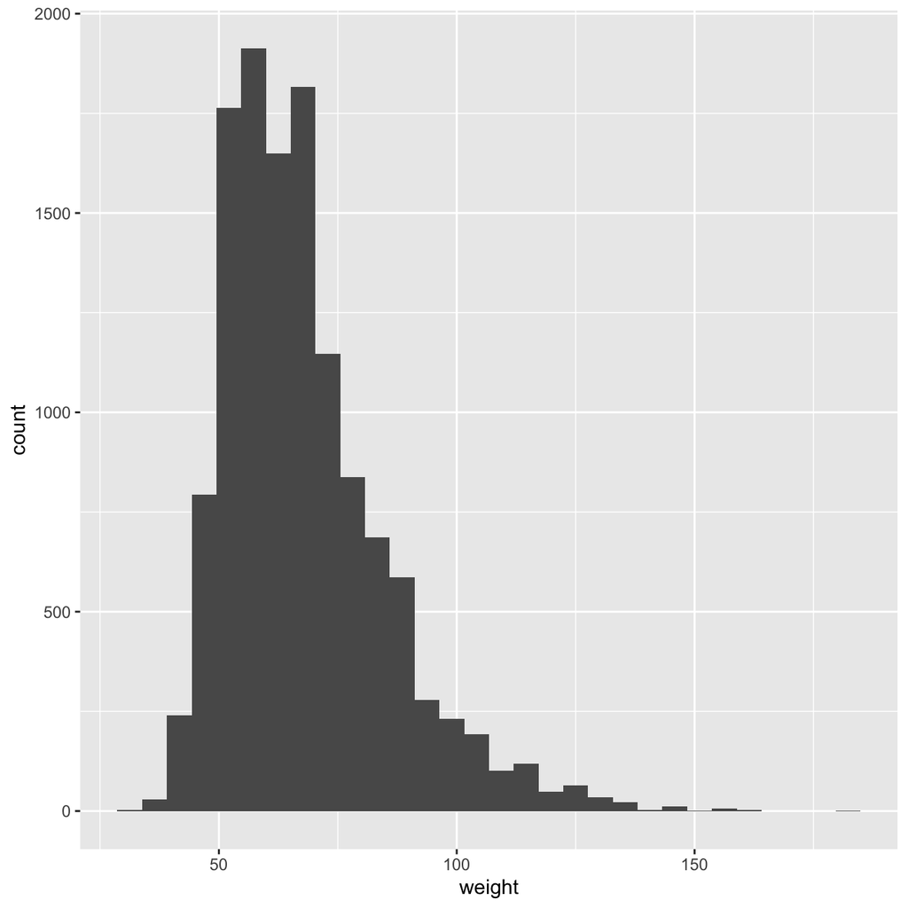

```r
# plot histogram
yrbss %>%
  filter(!is.na(weight)) %>%
  ggplot(aes(x=weight))+
  geom_histogram(bins=30)+
  NULL
```

- We can see that the distribution is right skewed and there are 1004 missing values.

Next, consider the possible relationship between a high schooler’s weight and their physical activity. Plotting the data is a useful first step because it helps us quickly visualize trends, identify strong associations, and develop research questions.

Let’s create a new variable in the dataframe `yrbss`, called `physical_3plus` , which will be `yes` if they are physically active for at least 3 days a week, and `no` otherwise. You may also want to calculate the number and % of those who are and are not active for more than 3 days. Use the `count()` function and see if you get the same results as `group_by()... summarise()`

```r
yrbss <- yrbss %>%
  mutate(physical_3plus = case_when(
    physically_active_7d >= 3 ~ "yes",
    physically_active_7d < 3 ~ "no",
    T ~ "NA"
  )) %>%
  filter(physical_3plus!="NA") # remove null values



# group by and summarise
yrbss %>%
  group_by(physical_3plus) %>%
  summarise(n = n()) %>%
  mutate(prop= n/sum(n))
```

```
## # A tibble: 2 × 3
##   physical_3plus     n  prop
##   <chr>          <int> <dbl>
## 1 no              4404 0.331
## 2 yes             8906 0.669
```

```r
# count
yrbss_prop <- yrbss %>%
 count(physical_3plus, sort=TRUE) %>%
 mutate(prop= n/sum(n))
```

Can you provide a 95% confidence interval for the population proportion of high schools that are *NOT* active 3 or more days per week?

```r
# notes: here std_error is the standard deviation of the sample mean

not_prop <- yrbss_prop %>%
  filter(physical_3plus=="no") %>%
  pull("prop")

not_n <- yrbss_prop %>%
  filter(physical_3plus=="no") %>%
  pull("n")
# estimation of sd
std_error <- sqrt(not_prop * (1-not_prop) / (sum(yrbss_prop$n) ))

# with unknown population sd, use t distribution 1.960503
t_critical <- qt(0.975, not_n - 1)

margin_of_error <- t_critical * std_error

# ci
phy_3plus_low <- not_prop - margin_of_error
phy_3plus_high <- not_prop + margin_of_error

print(sprintf("95%% confidence interval is [%f,%f]",phy_3plus_low,phy_3plus_high))
```

```
## [1] "95% confidence interval is [0.322883,0.338875]"
```

- 95% confidence interval is [0.322883,0.338875]

Make a boxplot of `physical_3plus` vs. `weight`. Is there a relationship between these two variables? What did you expect and why?

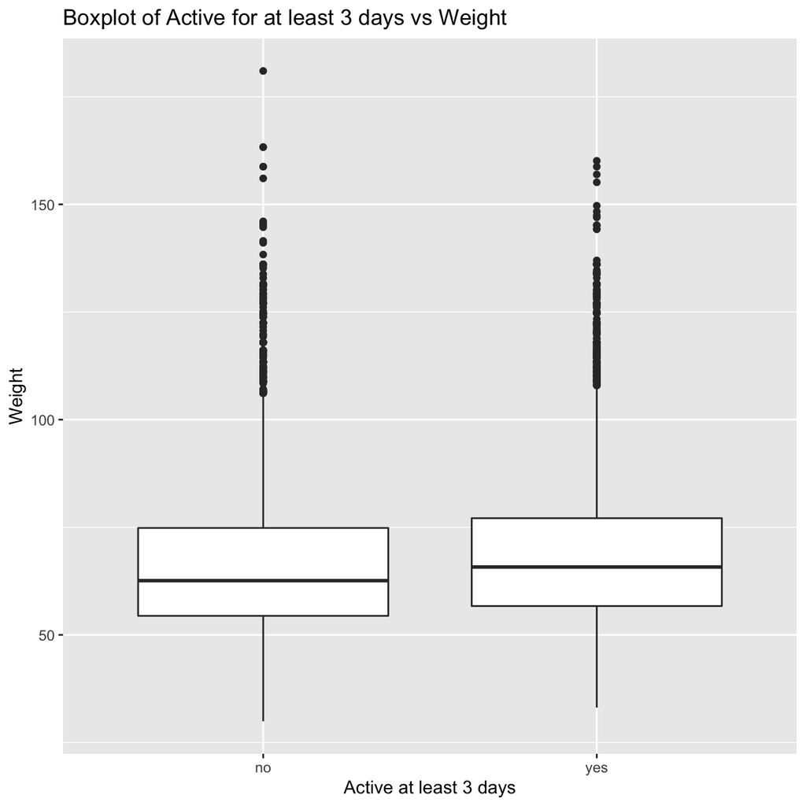

```r
yrbss %>%
  filter(physical_3plus!="NA") %>%
  ggplot(aes(x = physical_3plus , y = weight)) +
  geom_boxplot()+
  labs(title = "Boxplot of Active for at least 3 days vs Weight",
       x = "Active at least 3 days",
       y = "Weight")+
  NULL
```

## 1.3 Confidence Interval

Boxplots show how the medians of the two distributions compare, but we can also compare the means of the distributions using either a confidence interval or a hypothesis test. Note that when we calculate the mean/SD, etc weight in these groups using the mean function, we must ignore any missing values by setting the `na.rm = TRUE`.

```r
yrbss_stats <- favstats(weight~physical_3plus, data=yrbss,na.rm = T)

# use formulas
yrbss_stats_alt <- yrbss %>%
  group_by(physical_3plus) %>%
  summarise(avg_weight = mean(weight,na.rm=T),
            sd_weight_mean = sd(weight,na.rm=T),
            n=n())

#approximate by 1.96
t_critical <- 1.96 # qt(0.975, ) # calculate df with Welch-Satterhwaite formula

no_ci_lower <- 66.674 - t_critical*17.638/sqrt(4404)
no_ci_higher <- 66.674 + t_critical*17.638/sqrt(4404)
print(sprintf("weights of 'no': 95%% confidence interval is [%f,%f]",no_ci_lower,no_ci_higher))
```

```
## [1] "weights of 'no': 95% confidence interval is [66.153067,67.194933]"
```

```r
yes_ci_lower <- 68.448 - t_critical*16.478/sqrt(8906)
yes_ci_higher <- 68.448 + t_critical*16.478/sqrt(8906)
print(sprintf("weights of 'yes': 95%% confidence interval is [%f,%f]",yes_ci_lower,yes_ci_higher))
```

```
## [1] "weights of 'yes': 95% confidence interval is [68.105769,68.790231]"
```

There is an observed difference of about 1.77kg (68.44 - 66.67), and we notice that the two confidence intervals do not overlap. It seems that the difference is at least 95% statistically significant. Let us also conduct a hypothesis test.

## 1.4 Hypothesis test with formula

Write the null and alternative hypotheses for testing whether mean weights are different for those who exercise at least times a week and those who don’t.

Null hypothesis $H_0:\bar{weight}_{>=3h}-\bar{weight}_{<3h}=0$

Alternative hypothesis $H_1:\bar{weight}_{>=3h}-\bar{weight}_{<3h}\neq0$

```r
t.test(weight ~ physical_3plus, data = yrbss) # , var.equal=T) # assume different variance
```

```
##
##  Welch Two Sample t-test
##
## data:  weight by physical_3plus
## t = -5, df = 7479, p-value = 9e-08
## alternative hypothesis: true difference in means between group no and group yes is not equal to 0
## 95 percent confidence interval:
##  -2.42 -1.12
## sample estimates:
##  mean in group no mean in group yes
##              66.7              68.4
```

## 1.5 Hypothesis test with `infer`

Next, we will introduce a new function, `hypothesize`, that falls into the infer workflow. You will use this method for conducting hypothesis tests.

But first, we need to initialize the test, which we will save as `obs_diff`.

```r
obs_diff <- yrbss %>%
  specify(weight ~ physical_3plus) %>%
  calculate(stat = "diff in means", order = c("yes", "no"))

obs_diff
```

```
## Response: weight (numeric)
## Explanatory: physical_3plus (factor)
## # A tibble: 1 × 1
##    stat
##   <dbl>
## 1  1.77
```

Notice how you can use the functions specify and calculate again like you did for calculating confidence intervals. Here, though, the statistic you are searching for is the difference in means, with the order being yes - no != 0.

After you have initialized the test, you need to simulate the test on the null distribution, which we will save as null.

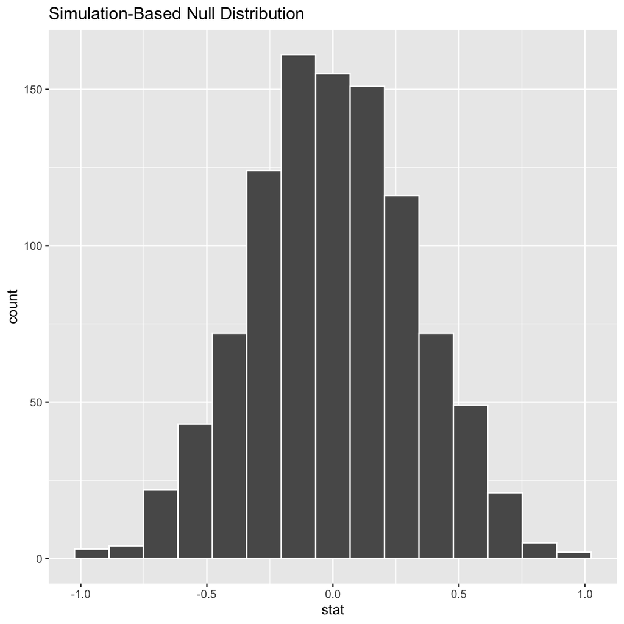

```r
null_dist <- yrbss %>%
  # specify variables
  specify(weight ~ physical_3plus) %>%

  # assume independence, i.e, there is no difference
  hypothesize(null = "independence") %>%

  # generate 1000 reps, of type "permute"
  generate(reps = 1000, type = "permute") %>%

  # calculate statistic of difference, namely "diff in means"
  calculate(stat = "diff in means", order = c("yes", "no"))

null_dist %>%
  visualise()
```

```r
# Warning: Please be cautious in reporting a p-value of 0. This result is an approximation based on the number of `reps` chosen in the `generate()` step.
p_value <- null_dist %>%
  get_pvalue(obs_stat = obs_diff, direction="both")
```

Here, `hypothesize` is used to set the null hypothesis as a test for independence, i.e., that there is no difference between the two population means. In one sample cases, the null argument can be set to *point* to test a hypothesis relative to a point estimate.

Also, note that the `type` argument within generate is set to permute, which is the argument when generating a null distribution for a hypothesis test.

We can visualize this null distribution with the following code:

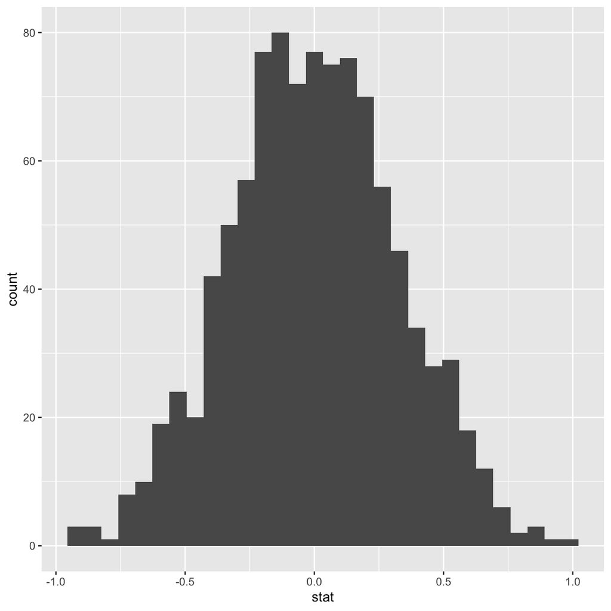

```r
ggplot(data = null_dist, aes(x = stat)) +
  geom_histogram()+
  NULL
```

Now that the test is initialized and the null distribution formed, we can visualise to see how many of these null permutations have a difference of at least `obs_stat` of 1.77?

We can also calculate the p-value for your hypothesis test using the function `infer::get_p_value()`.

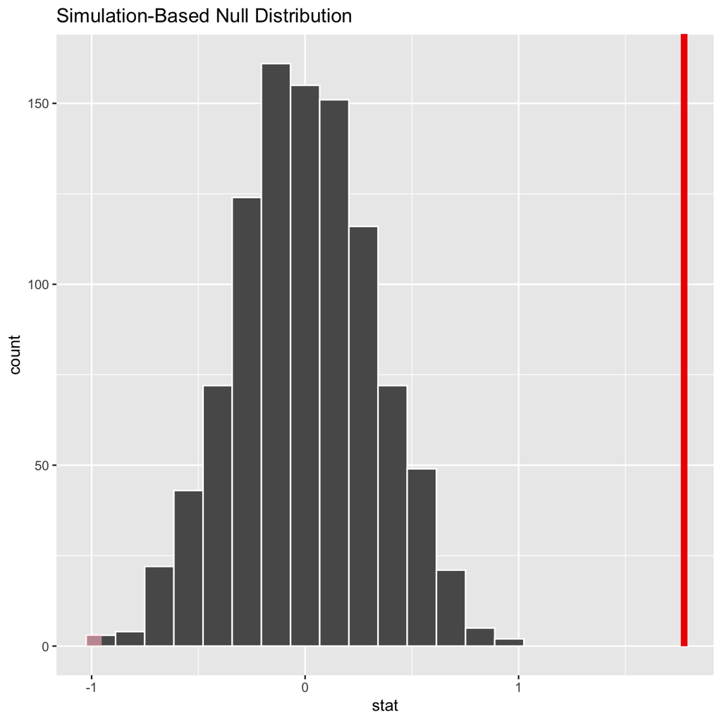

```r
null_dist %>% visualize() +
  shade_p_value(obs_stat = obs_diff, direction = "two-sided")
```

```r
null_dist %>%
  get_p_value(obs_stat = obs_diff, direction = "two_sided")
```

```
## # A tibble: 1 × 1
##   p_value
##     <dbl>
## 1       0
```

This the standard workflow for performing hypothesis tests.

# 2 IMDB ratings: Differences between directors

Recall the IMBD ratings data. I would like you to explore whether the mean IMDB rating for Steven Spielberg and Tim Burton are the same or not. I have already calculated the confidence intervals for the mean ratings of these two directors and as you can see they overlap.

First, I would like you to reproduce this graph. You may find `geom_errorbar()` and `geom_rect()` useful.

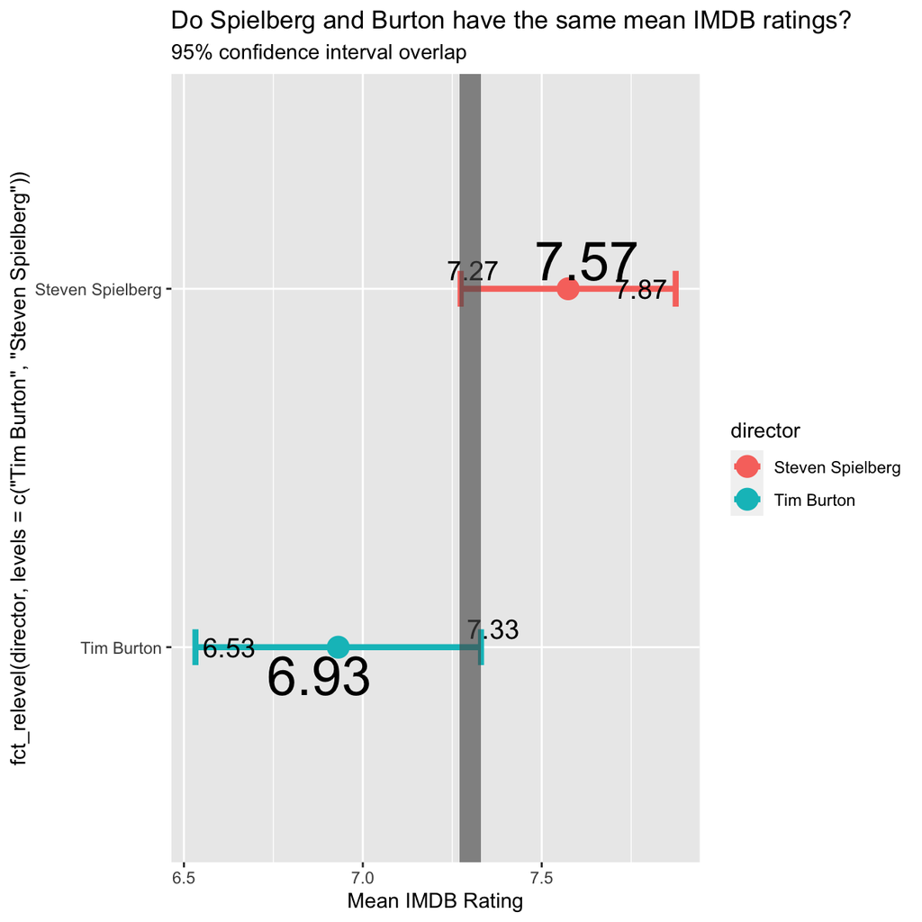

```r
movies <- read_csv(here::here('data', 'movies.csv'))

movies_comp <- movies %>%
  filter(director %in% c("Steven Spielberg","Tim Burton")) %>%
  group_by(director) %>%
  summarise(mean_rating = mean(rating),
            std_rating = sd(rating),
            count=n(),
            se_rating = std_rating / sqrt(count),
            t_critical = qt(0.975, count-1),
            margin_of_error = t_critical * se_rating,
            rating_low = mean_rating - margin_of_error,
            rating_high = mean_rating + margin_of_error) %>%
  arrange(desc(mean_rating))

movies_comp %>%
  ggplot(mapping = aes(x=mean_rating,y=fct_relevel(director, levels=c("Tim Burton","Steven Spielberg"))))+

  geom_point(size = 5, mapping = aes(color = director))+
  geom_errorbar(aes(xmin = rating_low, xmax = rating_high, color = director), width = 0.1,size = 1.5)+
  ggrepel::geom_text_repel(aes(x=mean_rating, label = round(mean_rating, 2)), size=10, position = position_dodge(0.9)) +
  ggrepel::geom_text_repel(aes(x=rating_low, label = round(rating_low, 2)),size = 5, position = position_dodge(0.9)) +
  ggrepel::geom_text_repel(aes(x=rating_high, label = round(rating_high, 2)),size = 5, position = position_dodge(0.9)) +
  # geom_text(aes(label = round(mean_rating,digits=2)), position = position_dodge(0.9),vjust=-2,size = 10)+
  geom_rect(xmin = 7.27,xmax = 7.33, ymin=0, ymax=Inf, alpha=0.4)+
  labs(title = "Do Spielberg and Burton have the same mean IMDB ratings?",
       subtitle = "95% confidence interval overlap",
       x = "Mean IMDB Rating") +
  NULL
```

In addition, you will run a hpothesis test. You should use both the `t.test` command and the `infer` package to simulate from a null distribution, where you assume zero difference between the two.

> Before anything, write down the null and alternative hypotheses, as well as the resulting test statistic and the associated t-stat or p-value. At the end of the day, what do you conclude?

You can load the data and examine its structure

```r
movies_comp
```

```
## # A tibble: 2 × 9
##   director         mean_rating std_rating count se_rating t_critical margin_of_error
##   <chr>                  <dbl>      <dbl> <int>     <dbl>      <dbl>           <dbl>
## 1 Steven Spielberg        7.57      0.695    23     0.145       2.07           0.301
## 2 Tim Burton              6.93      0.749    16     0.187       2.13           0.399
## # … with 2 more variables: rating_low <dbl>, rating_high <dbl>
```

```r
t_stat =  (7.57-6.93)/sqrt(0.695*0.695/23 + 0.749*0.749/16)
# p_value = 2*0.0035
p_value = 2*(1-pt(2.7,37))
t_stat
```

```
## [1] 2.7
```

```r
p_value
```

```
## [1] 0.0104
```

```r
movies <- read_csv(here::here("data", "movies.csv"))
glimpse(movies)
```

```
## Rows: 2,961
## Columns: 11
## $ title               <chr> "Avatar", "Titanic", "Jurassic World", "The Avenge…
## $ genre               <chr> "Action", "Drama", "Action", "Action", "Action", "…
## $ director            <chr> "James Cameron", "James Cameron", "Colin Trevorrow…
## $ year                <dbl> 2009, 1997, 2015, 2012, 2008, 1999, 1977, 2015, 20…
## $ duration            <dbl> 178, 194, 124, 173, 152, 136, 125, 141, 164, 93, 1…
## $ gross               <dbl> 7.61e+08, 6.59e+08, 6.52e+08, 6.23e+08, 5.33e+08, …
## $ budget              <dbl> 2.37e+08, 2.00e+08, 1.50e+08, 2.20e+08, 1.85e+08, …
## $ cast_facebook_likes <dbl> 4834, 45223, 8458, 87697, 57802, 37723, 13485, 920…
## $ votes               <dbl> 886204, 793059, 418214, 995415, 1676169, 534658, 9…
## $ reviews             <dbl> 3777, 2843, 1934, 2425, 5312, 3917, 1752, 1752, 35…
## $ rating              <dbl> 7.9, 7.7, 7.0, 8.1, 9.0, 6.5, 8.7, 7.5, 8.5, 7.2, …
```

```r
movies_hypo <- movies %>%
  filter(director %in% c("Steven Spielberg","Tim Burton"))

t.test(rating ~ director, data = movies_hypo)
```

```
##
##  Welch Two Sample t-test
##
## data:  rating by director
## t = 3, df = 31, p-value = 0.01
## alternative hypothesis: true difference in means between group Steven Spielberg and group Tim Burton is not equal to 0
## 95 percent confidence interval:
##  0.16 1.13
## sample estimates:
## mean in group Steven Spielberg       mean in group Tim Burton
##                           7.57                           6.93
```

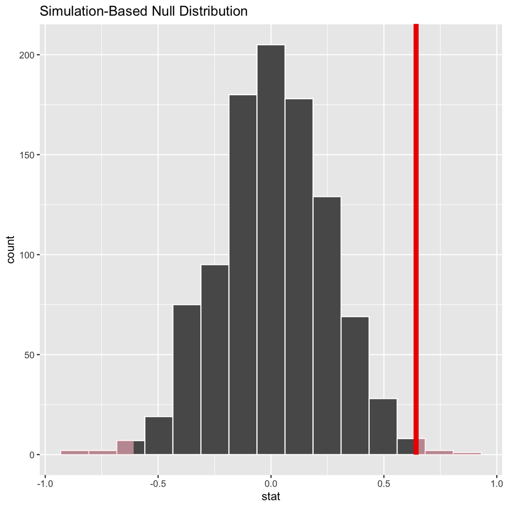

```r
diff <- movies_hypo %>%
  specify(rating ~ director) %>%
  calculate(stat = "diff in means", order = c("Steven Spielberg", "Tim Burton"))

set.seed(1234)
null_dist_movies <- movies_hypo %>%
  # specify variables
  specify(rating ~ director) %>%

  # assume independence, i.e, there is no difference
  hypothesize(null = "independence") %>%

  # generate 1000 reps, of type "permute"
  generate(reps = 1000, type = "permute") %>%

  # calculate statistic of difference, namely "diff in means"
  calculate(stat = "diff in means", order = c("Steven Spielberg", "Tim Burton"))

null_dist_movies %>%
  visualise()+
  shade_p_value(obs_stat = diff, direction = "two-sided")
```

```r
p_value <- null_dist_movies %>%
  get_pvalue(obs_stat = diff, direction="both")

p_value
```

```
## # A tibble: 1 × 1
##   p_value
##     <dbl>
## 1   0.008
```

# 3 Omega Group plc- Pay Discrimination

At the last board meeting of Omega Group Plc., the headquarters of a large multinational company, the issue was raised that women were being discriminated in the company, in the sense that the salaries were not the same for male and female executives. A quick analysis of a sample of 50 employees (of which 24 men and 26 women) revealed that the average salary for men was about 8,700 higher than for women. This seemed like a considerable difference, so it was decided that a further analysis of the company salaries was warranted.

You are asked to carry out the analysis. The objective is to find out whether there is indeed a significant difference between the salaries of men and women, and whether the difference is due to discrimination or whether it is based on another, possibly valid, determining factor.

## 3.1 Loading the data

```r
omega <- read_csv(here::here("data", "omega.csv"))
glimpse(omega) # examine the data frame
```

```
## Rows: 50
## Columns: 3
## $ salary     <dbl> 81894, 69517, 68589, 74881, 65598, 76840, 78800, 70033, 635…
## $ gender     <chr> "male", "male", "male", "male", "male", "male", "male", "ma…
## $ experience <dbl> 16, 25, 15, 33, 16, 19, 32, 34, 1, 44, 7, 14, 33, 19, 24, 3…
```

## 3.2 Relationship Salary - Gender ?

The data frame `omega` contains the salaries for the sample of 50 executives in the company. Can you conclude that there is a significant difference between the salaries of the male and female executives?

Note that you can perform different types of analyses, and check whether they all lead to the same conclusion

. Confidence intervals . Hypothesis testing . Correlation analysis . Regression

Calculate summary statistics on salary by gender. Also, create and print a dataframe where, for each gender, you show the mean, SD, sample size, the t-critical, the SE, the margin of error, and the low/high endpoints of a 95% condifence interval

```r
# Summary Statistics of salary by gender
mosaic::favstats (salary ~ gender, data=omega) %>%

# Dataframe with two rows (male-female) and having as columns gender, mean, SD, sample size,
# the t-critical value, the standard error, the margin of error,
# and the low/high endpoints of a 95% condifence interval
  mutate(t_critical = qt(0.975,n-1),
         sd_mean = sd/sqrt(n),
         margin_of_error = t_critical*sd_mean,
         ci_lower = mean-margin_of_error,
         ci_higher = mean+margin_of_error)
```

```
##   gender   min    Q1 median    Q3   max  mean   sd  n missing t_critical
## 1 female 47033 60338  64618 70033 78800 64543 7567 26       0       2.06
## 2   male 54768 68331  74675 78568 84576 73239 7463 24       0       2.07
##   sd_mean margin_of_error ci_lower ci_higher
## 1    1484            3056    61486     67599
## 2    1523            3151    70088     76390
```

> What can you conclude from your analysis? A couple of sentences would be enough
- Since two 95% confidence intervals do not overlap, we are at least 95% confident that the male have higher omega than the female in average.

You can also run a hypothesis testing, assuming as a null hypothesis that the mean difference in salaries is zero, or that, on average, men and women make the same amount of money. You should tun your hypothesis testing using `t.test()` and with the simulation method from the `infer` package.

```r
# hypothesis testing using t.test()
t.test(salary ~ gender, data=omega)
```

```
##
##  Welch Two Sample t-test
##
## data:  salary by gender
## t = -4, df = 48, p-value = 2e-04
## alternative hypothesis: true difference in means between group female and group male is not equal to 0
## 95 percent confidence interval:
##  -12973  -4420
## sample estimates:
## mean in group female   mean in group male
##                64543                73239
```

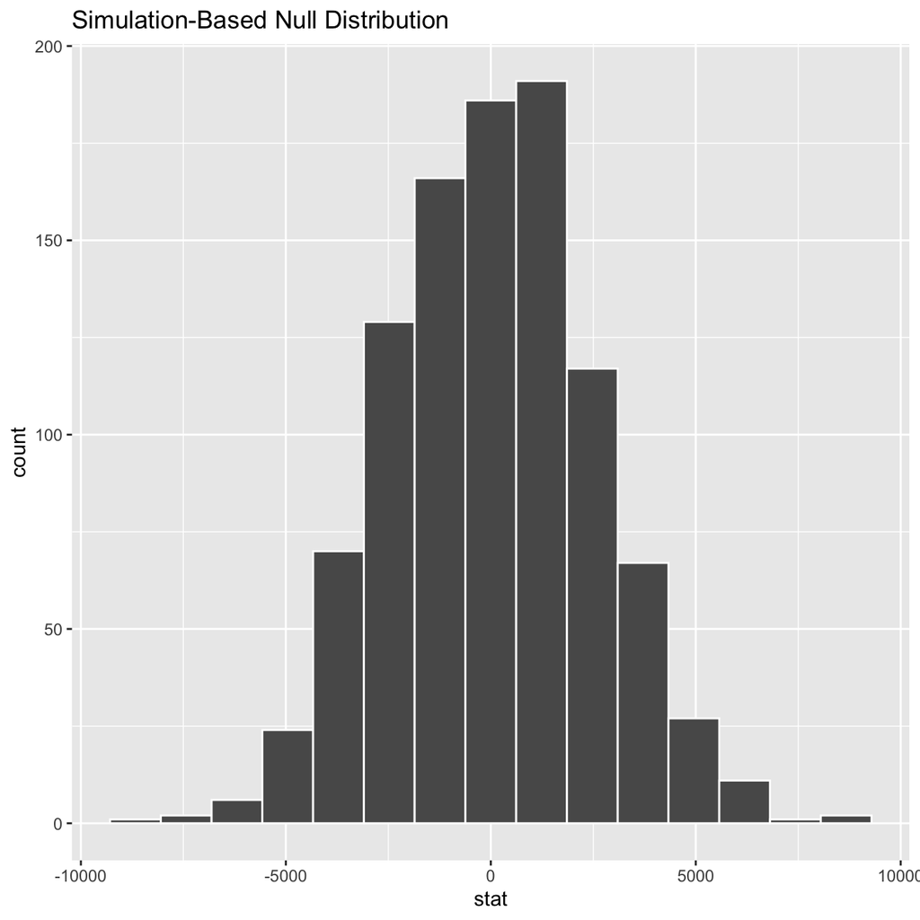

```r
# hypothesis testing using infer package
obs_diff <- omega %>%
  specify(salary ~ gender) %>%
  calculate(stat = "diff in means", order = c("female", "male"))

null_dist <- omega %>%
  # specify variables
  specify(salary ~ gender) %>%

  # assume independence, i.e, there is no difference
  hypothesize(null = "independence") %>%

  # generate 1000 reps, of type "permute"
  generate(reps = 1000, type = "permute") %>%

  # calculate statistic of difference, namely "diff in means"
  calculate(stat = "diff in means", order = c("female", "male"))

null_dist %>%
  visualise()
```

```r
# Warning: Please be cautious in reporting a p-value of 0. This result is an approximation based on the number of `reps` chosen in the `generate()` step.
p_value <- null_dist %>%
  get_pvalue(obs_stat = obs_diff, direction="both")
```

> What can you conclude from your analysis? A couple of sentences would be enough
- Here our null hypothesis is that the difference of omega between male and female is 0 and we get a p_value very close to 0. Therefore we reject the null hypothesis with 95% confidence.

## 3.3 Relationship Experience - Gender?

At the board meeting, someone raised the issue that there was indeed a substantial difference between male and female salaries, but that this was attributable to other reasons such as differences in experience. A questionnaire send out to the 50 executives in the sample reveals that the average experience of the men is approximately 21 years, whereas the women only have about 7 years experience on average (see table below).

```r
# Summary Statistics of salary by gender
favstats (experience ~ gender, data=omega)
```

```
##   gender min    Q1 median   Q3 max  mean    sd  n missing
## 1 female   0  0.25    3.0 14.0  29  7.38  8.51 26       0
## 2   male   1 15.75   19.5 31.2  44 21.12 10.92 24       0
```

Based on this evidence, can you conclude that there is a significant difference between the experience of the male and female executives? Perform similar analyses as in the previous section. Does your conclusion validate or endanger your conclusion about the difference in male and female salaries?

## 3.4 Relationship Salary - Experience ?

Someone at the meeting argues that clearly, a more thorough analysis of the relationship between salary and experience is required before any conclusion can be drawn about whether there is any gender-based salary discrimination in the company.

Analyse the relationship between salary and experience. Draw a scatterplot to visually inspect the data

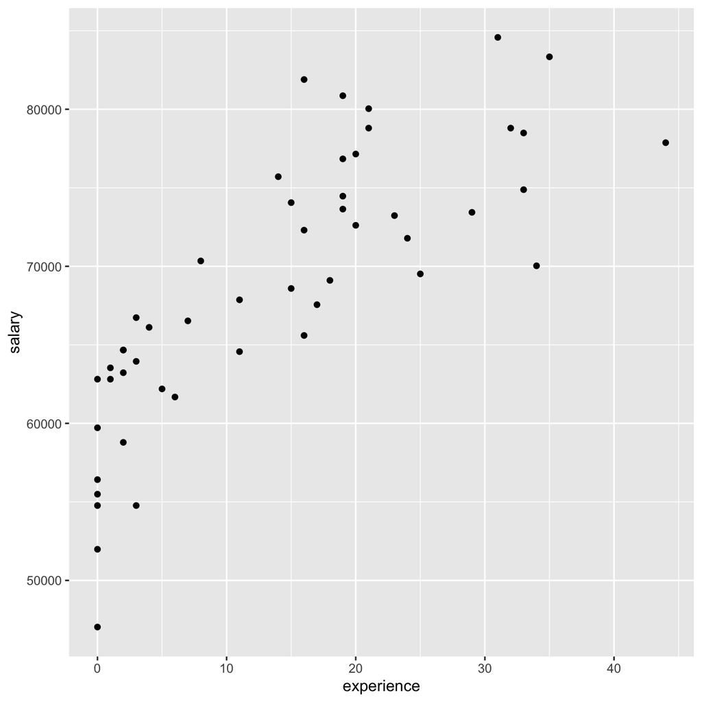

```r
omega %>%
  ggplot(aes(x=experience, y=salary)) +
  geom_point()+
  #labs()+
  NULL
```